# 2021030_HW4

Kinsey Reed

3/10/2021

y: response variable (counts of the number of events) x1: continuous predictor variable x2: categorical predictor variable with 2 levels: "a" and "b"

1. Fit a Poisson regression model that assumes expected count is an interactive function of variables x1 and x2.

```r
data <- read.csv('Homework 4 Data.csv')
head(data)
```

```
##    y         x1 x2
## 1  4 -2.4335748  a
## 2  3 -0.6850696  b
## 3  5 -0.8038049  a
## 4  5  2.1243703  b
## 5  2 -0.3157032  b
## 6 10  0.1981158  a
```

```r
fit <- glm(y ~ x1 * x2, family = poisson, data = data)
summary(fit)
```

```
##
## Call:
## glm(formula = y ~ x1 * x2, family = poisson, data = data)
##
## Deviance Residuals:
##     Min       1Q   Median       3Q      Max
## -2.1523  -0.6131  -0.1399   0.4250   2.5643
##
## Coefficients:
##             Estimate Std. Error z value Pr(>|z|)
## (Intercept)  1.85710    0.05822  31.896  < 2e-16 ***
## x1          -0.09937    0.06353  -1.564 0.117778
## x2b         -1.04662    0.11283  -9.276  < 2e-16 ***
## x1:x2b       0.47840    0.12314   3.885 0.000102 ***
## ---
## Signif. codes:  0 '***' 0.001 '**' 0.01 '*' 0.05 '.' 0.1 ' ' 1
##
## (Dispersion parameter for poisson family taken to be 1)
##
##     Null deviance: 208.324  on 99  degrees of freedom
## Residual deviance:  84.732  on 96  degrees of freedom
## AIC: 405.67
##
## Number of Fisher Scoring iterations: 4
```

2. Interpret the effect of variable x1 on the expected count when x2 is fixed at level "b". Verify your interpretation in R.

Each additional unit of variable x1, when fixed at level "b", causes a 46.1% increase in the proportional change in expected count.

```r
B <- coef(fit)
#1-unit change in x1 with x2 fixed at b (1)
c_0 <- B[1] + B[3]
c_1 <- B[1] + B[2] + B[3] + B[4]

#log of the ratio of expected counts
log(exp(c_1)/exp(c_0)); B[2] + B[4]
```

```
## (Intercept)
##   0.3790225
```

```
##        x1
## 0.3790225
```

```r
#the proportional change in expected count
exp(c_1) / exp(c_0); exp(B[2] + B[4])
```

```
## (Intercept)
##    1.460856
```

```
##       x1
## 1.460856
```

```r
#% increase
(exp(B[2] + B[4])-1)*100
```

```
##       x1
## 46.08559
```

3. Interpret the effect of variable x2 on the expected count when x1 is fixed at 1. Verify your interpretation in R.

There is a 43.3% decrease in the proportional change of expected count between levels a and b,when x1 is fixed at 1.

```r
#1-unit change in x2 with x1 = 1
ct_0 <- B[1] + B[2]
ct_1 <- B[1] + B[2] + B[3] + B[4]

#log of the ratio of expected counts
log(exp(ct_1)/exp(ct_0)); B[3] + B[4]
```

```
## (Intercept)
##  -0.5682285
```

```
##        x2b
## -0.5682285
```

```r
#the proportional change in expected count
exp(ct_1) / exp(ct_0); exp(B[3] + B[4])
```

```
## (Intercept)
##   0.5665282
```

```
##       x2b
## 0.5665282
```

```r
#% increase
(exp(B[3] + B[4])-1)*100
```

```
##       x2b
## -43.34718
```

4. Predict the expected count, ± 95% confidence intervals, over the observed range of values of x1, assuming x2 is fixed at level "b".

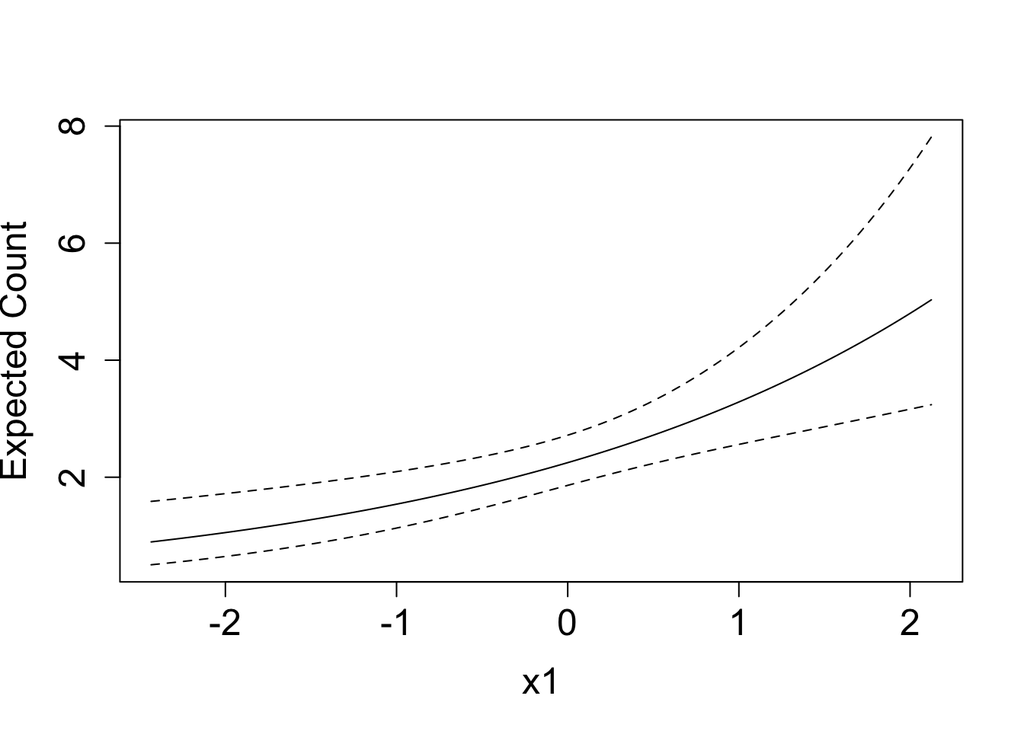

```r
#data frame of predicted values
nd <- data.frame(
  x1 = seq(min(data$x1), max(data$x1), length.out = 100),
  x2 = factor(x = rep('b', times = 100),
               levels = c('a', 'b'))
)

#predict
prd <- predict.glm(object = fit, newdata = nd, type = 'link', se.fit = T)
low <- exp(prd$fit - qnorm(0.975) * prd$se.fit)
high <- exp(prd$fit + qnorm(0.975) * prd$se.fit)

#plotting
plot(y = exp(prd$fit), x = nd$x1, xlab = 'x1',
     ylab = 'Expected Count', cex.axis = 1.5, cex.lab = 1.5,
     ylim = c(min(low), max(high)), type = 'l')
lines(x = nd$x1, y = low, lty = 2)
lines(x = nd$x1, y = high, lty = 2)
```

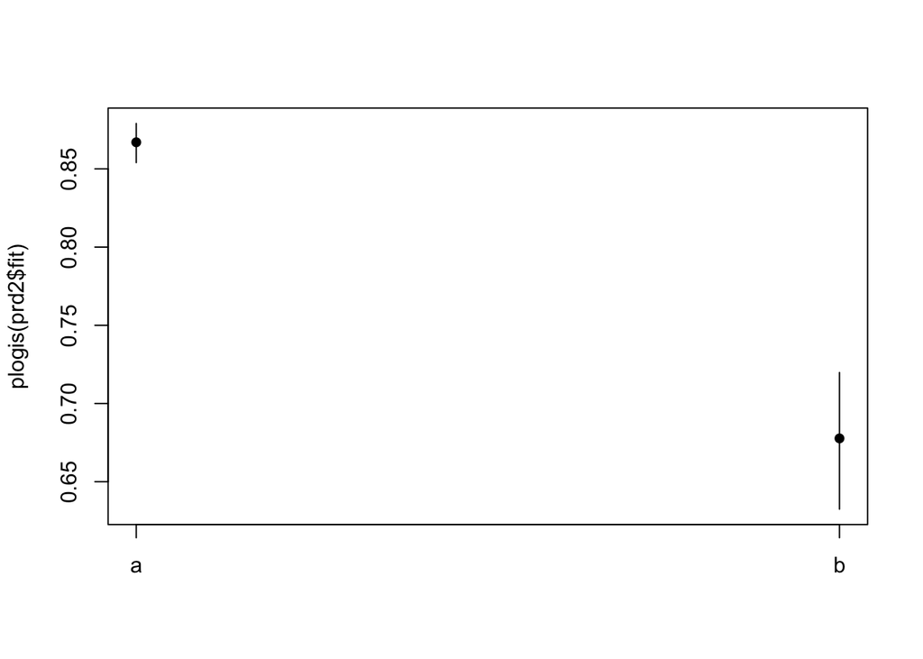

```r
#df with x1 held at mean

x1_ = c(mean(data$x1), mean(data$x1))
x2_ = factor(c('a', 'b'))

df <- data.frame(
  x1 = x1_,
  x2 = x2_
  )
#predict expected count
prd2 <- predict.glm(fit, df, type = 'link', se.fit = T)
low2 <- prd2$fit - qnorm(0.975) * prd2$se.fit
high2 <- prd2$fit + qnorm(0.975) * prd2$se.fit

plot(y = plogis(prd2$fit), x = c(1, 2), pch = 16,
ylim = c(min(plogis(low2)), max(plogis(high2))),
xaxt = 'n', xlab = '')
axis(side = 1, at = c(1, 2), labels = c('a', 'b'))
lines(x = c(1, 1), y = plogis(c(low2[1], high2[1])))
lines(x = c(2, 2), y = plogis(c(low2[2], high2[2])))
```